# ELISA data analysis

Paloma

# Overview

This file documents all the transformations done to obtain final cortisol values for the ELISA plate called:

```
Test7
```

This is how final values were obtained:

```
|-- Plate reader produces optical density (OD) values
      |---> Myassays.com uses ODs and map of plate layout to:

           1) Subtract readings for the NSB (non-specific binding, 0% binding) well
              from all values

           2) Normalize all values, dividing them by the reading for the zero standard
              (blank, or B0, 100% binding)

           3) Fit a 4-Parameter Logistic curve (for a sigmoidal shape)
              to the standard readings

           4) Extrapolate cortisol concentration values from the standard curve
                  * Obtained values for each replicate separately by
                  treating them as a single sample when providing
                  the plate layout
                  * These values do not control for differences
                  in dilution, sample weight, spike, etc.
                  * Values obtained are in the same unit as the
                  standards provided (pg/ml)
                  * Flagged samples were labeled as such in SampleInfo.csv file
                       |----> In R, I calculate final values using two formulas:
                              A) Traditional used across studies
                              B) Alternative, accounts for Spike (when necessary)
```

Check Rmarkdown file to see the code used to clean and merge data frames.

## Input files

All located in ./HairCort-Evaluation-Nist2020/data/TestX

- **Results**:

```
ResultsMyAssaysIndiv_T7.csv
```

- **Results for Standards**:

```
ResultsMyAssaysIndiv_T7_st.csv
```

- **Sample information**:

```
SampleInfo.csv
```

# Results

## Binding Percentages and non-normalized cort values

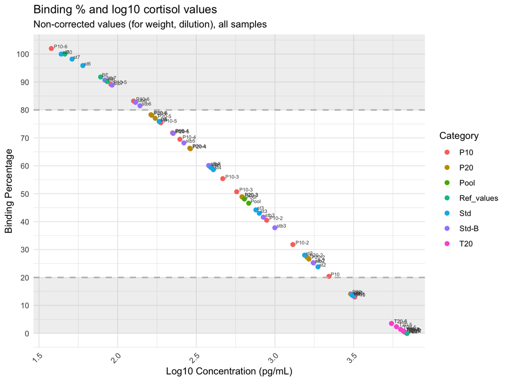

**Warning!** The custom `fig.path` you set was ignored by workflowr.

## Binding Percentages by Sample

```
Warning: Removed 1 row containing missing values or values outside the scale range (`geom_point()`).
```

```
Warning: Removed 1 row containing missing values or values outside the scale range (`geom_text()`).
```

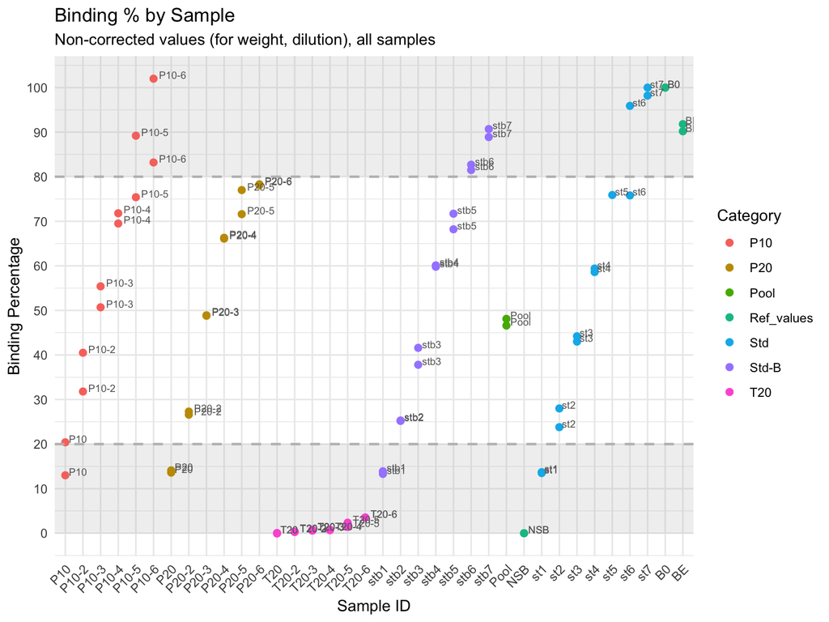

**Warning!** The custom `fig.path` you set was ignored by workflowr.

## Binding Percentages by Sample, filtered out flagged samples

```
Warning: Removed 1 row containing missing values or values outside the scale range (`geom_point()`).
```

```
Warning: Removed 1 row containing missing values or values outside the scale range (`geom_text()`).
```

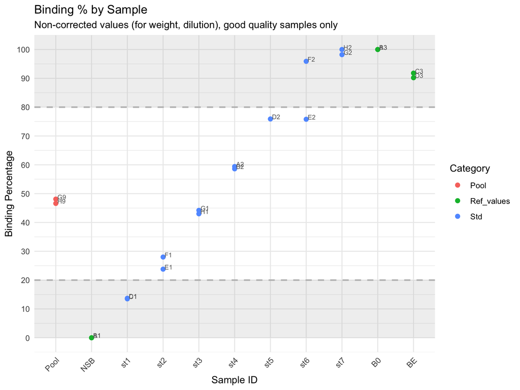

**Warning!** The custom `fig.path` you set was ignored by workflowr.

## Binding Percentages by Sample, averaged for replicates

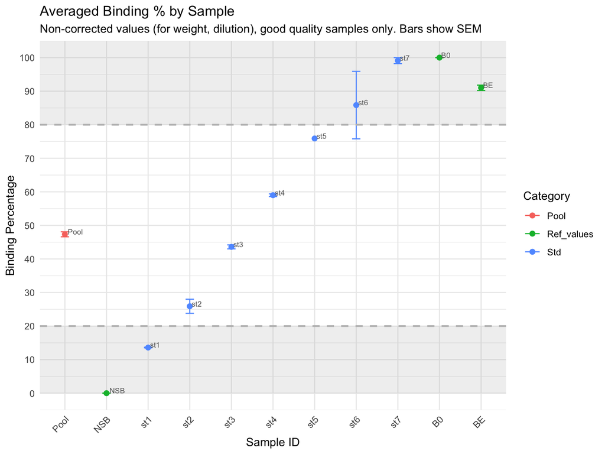

**Warning!** The custom `fig.path` you set was ignored by workflowr.

## Analyses by Hair Count (if information exists)

```
Skipping plot, data set does not have information on
    the number of hair strands
```

```
Skipping plot, data set does not have information on
    the number of hair strands
```

```
Skipping plot, data set does not have information on
    the number of hair strands
```

```
Skipping plot, data set does not have information on
    the number of hair strands
```

```
Skipping plot, data set does not have information on
    the number of hair strands
```

[output not shown]

# Calculating final, normalized values

## Formula A (traditional)

```
    A * F / B * C / D * E = Cortisol concentration in pg/mg

    ▪ A = output myassays.com (pg/ml)
    ▪ B = sample mass (mg)
    ▪ C = methanol added for extraction (mL)
    ▪ D = methanol recovered (mL)
    ▪ E = reconstitution volume (mL)
    ▪ F = Sample dilution factor (2 if 1:2, 4 if 1:4)
```

```r
############################################################
##### Calculate final values not accounting for spike #####
############################################################

data$Final_pg_mg <-
     (data$Conc_pg_ml * data$Dilution_factor_sample
      / data$Weight_mg) *            # A / B *
     data$Extraction_ratio *         # C / D *
     data$Reconst_buffer_ml          # E
```

## Formula B (accounting for spike)

Simplifies unnecessary unit transformations and accounts for spike considering dilution of both sample and the spike

- Step 1: Calculate contribution of the spike
- Step 2: Subtract spike from plate reading values and calculate final values accounting for dilution of the sample, weight, and reconstitution

**Step 1**: Calculate contribution of spike

X * Y / Z / SPd = SP

- SP = final value of spike contribution in pg/mL
- X = volume of spike added (mL)
- Y = concentration of the spike added (pg/mL)
- SPd = if serially diluted, dilution factor for the spike (i.e: 1, 2, 4, 8, etc.)
- Z = total volume (mL) in the well or tube, if spike is added before loading the plate (sample + spike)

```r
# Calculating contribution of the spike

# consider spike volume added, either in the tube or the well
data$SpikeVol_ml <- data$Spike_well_ml + data$Spike_tube_ml

# consider total volume of liquid added to the well, adding up spike, buffer and sample volumes
data$TotalVol_ml  <- data$Spike_well_ml + data$Sample_well_ml + data$Buffer_well_ml

# reading for the standard used to spike samples
# I already run the following line, to save the std readings before overwritting the Ave_conc_pg_ml object
# std <- data[data$Sample == spike_std, c("Ave_conc_pg_ml")]

# average both readings
std <- mean(std)

# Calculate spike contribution to each sample
      ##  ( Spike vol. x Spike Conc.)
      ##   ------------------------  / dilution = Spike contribution (pg/ml)
      ##        Total vol.

# Calculate cort contribution of spike to each sample
data$Spike_contribution <- ((data$SpikeVol_ml * std  /     # X * Y /
                            data$TotalVol_ml ) /           # Z /
                              data$Dilution_factor_spike)  # SPd

# Null contributions equal zero
data <- data %>%
mutate(Spike_contribution = ifelse(is.na(Spike_contribution) | is.nan(Spike_contribution), 0, Spike_contribution))
```

[output not shown]

```
The contribution of the spike, considering how much is added to the well, is 0 pg/ml
```

**Step 2** : Substract spike and calculate final values

((A - **SP**)/B) * (C/D) * E = F

- A = pg/ml from assay output;
- *SP* = spike contribution (in pg/ml)
- B = weight (in mg) of hair subjected to extraction;
- C = vol. (in ml) of methanol added to the powdered hair;
- D = vol. (in ml) of methanol recovered from the extract and subsequently dried down;
- E = vol. (in ml) of assay buffer used to reconstitute the dried extract;
- F = final value of hair CORT Concentration in pg/mg.

```r
##################################
##### Calculate final values #####
##################################

data$Final_pg_mg_sp <-
     (
       (data$Conc_pg_ml - data$Spike_contribution) * #  (A - spike)
         data$Dilution_factor_sample) /  #  * dilution factor /
     data$Weight_mg *                    # B *
     data$Extraction_ratio *             # C / D *
     data$Reconst_buffer_ml              # E
```

### Results Formula B

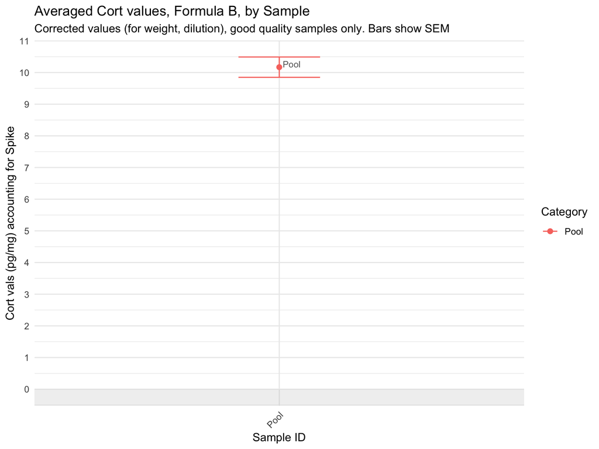

**Warning!** The custom `fig.path` you set was ignored by workflowr.

# Quality

Flag samples with high coefficient of variation (replicate measurements that are too different from each other) or that fall outside the standard curve (binding percentage is above 80%, or under 20%)

```r
# flag samples with high CV (15%) or binding above 80% and under 20%
CV_threshold <- 15.0
uppBinLim <- 80.0
lowBinLim <- 20.0
```

```
Total samples outside the curve: 11 (some are blanks or NSB)
```

```
# A tibble: 11 × 3
   Well  Sample Category
   <chr> <fct>  <fct>
 1 A1    NSB    Ref_values
 2 B1    NSB    Ref_values
 3 C1    st1    Std
 4 D1    st1    Std
 5 F2    st6    Std
 6 G2    st7    Std
 7 H2    st7    Std
 8 A3    B0     Ref_values
 9 B3    B0     Ref_values
10 C3    BE     Ref_values
11 D3    BE     Ref_values
```

```
High CV in a total of 0 replicates. These are:
```

```
# A tibble: 0 × 3
# ℹ 3 variables: Well <chr>, Sample <fct>, Category <fct>
```

```
Warning in fortify(data, ...): Arguments in `...` must be used.
✖ Problematic argument:
• group = Binding_perc_categ
ℹ Did you misspell an argument name?
```

```
Warning: Removed 4 rows containing missing values or values outside the scale range (`geom_point()`).
```

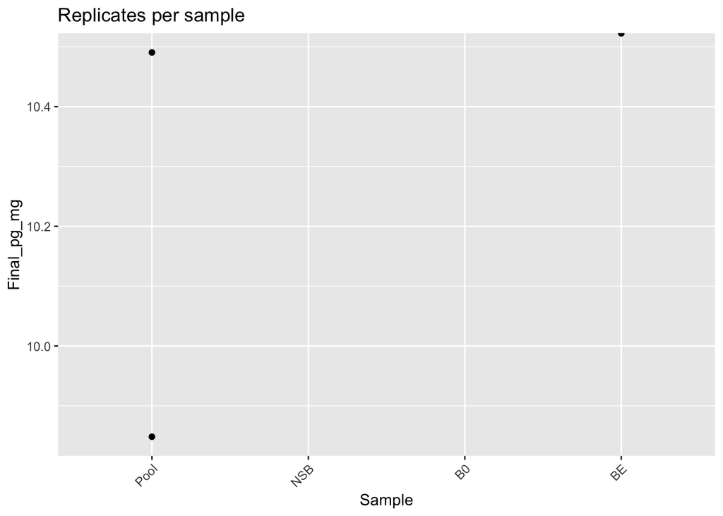

**Warning!** The custom `fig.path` you set was ignored by workflowr.

[output not shown]

```
Summary final cortisol values for all samples
```

```
   Min. 1st Qu.  Median    Mean 3rd Qu.    Max.    NA's
  9.848  10.330     Inf     Inf     Inf     Inf      18
```

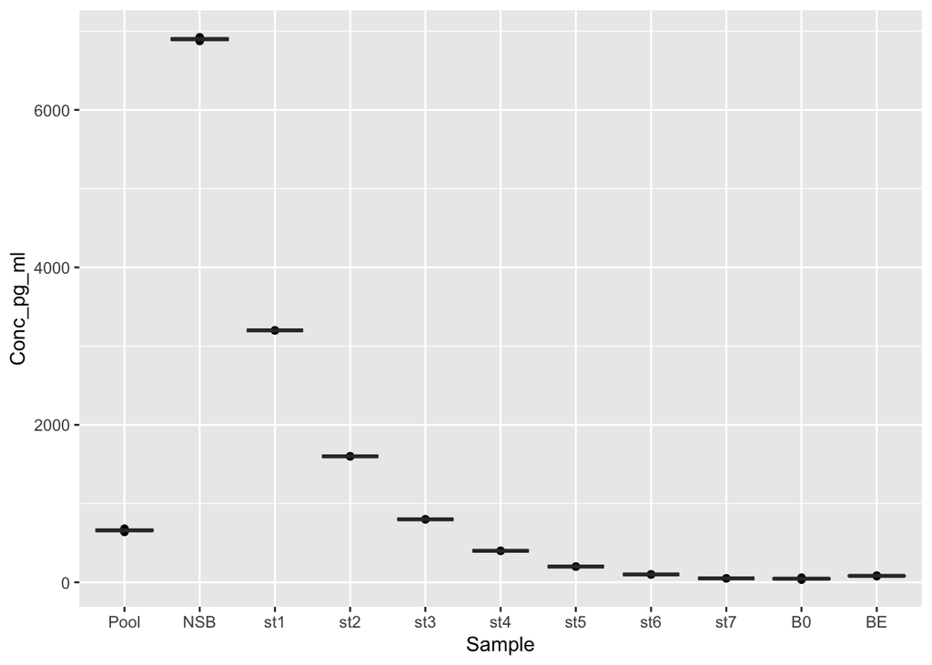

**Warning!** The custom `fig.path` you set was ignored by workflowr.

## Plot: results grouped by category

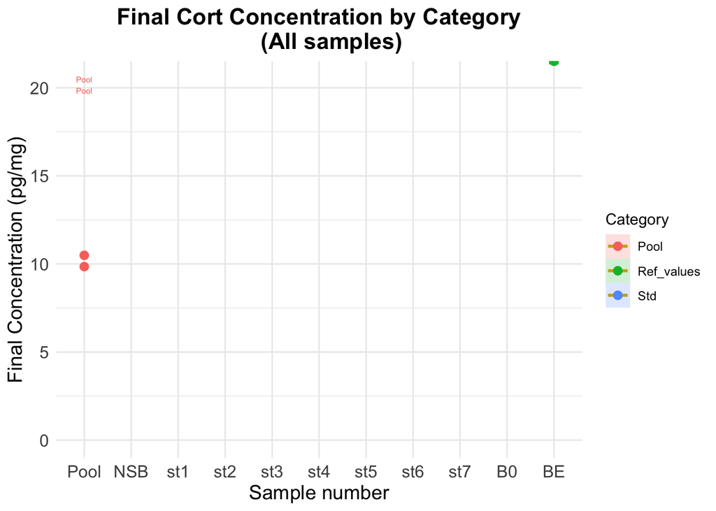

**Warning!** The custom `fig.path` you set was ignored by workflowr.

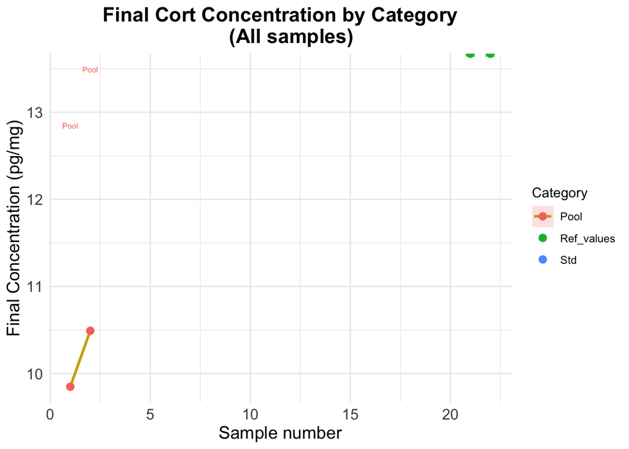

**Warning!** The custom `fig.path` you set was ignored by workflowr.

## Plot: results grouped by data quality

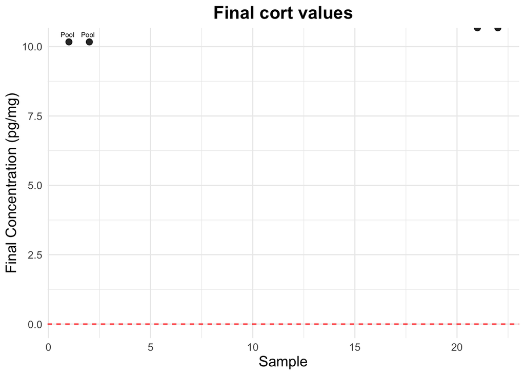

**Warning!** The custom `fig.path` you set was ignored by workflowr.

```
Wrote 22 rows to /Users/palomacz/Documents/GitHub/HairCort-Evaluation-Nist2020/data/Test7/Merged_ELISA_results_Test7.csv, with a total of 11 data points, including reference values such as blanks and standards
```

```
The final file has the following columns:
```

```
 [1] "Plate_num"              "Well"                   "Sample"                 "Category"
 [5] "Subcategory"            "Person"                 "Order"                  "Num_strands"
 [9] "Weight_mg"              "Reconst_buffer_ml"      "Sample_well_ml"         "Buffer_well_ml"
[13] "Buffer_tube_ml"         "Dilution_factor_sample" "Spike"                  "Spike_well_ml"
[17] "Spike_tube_ml"          "Dilution_factor_spike"  "Extraction_ratio"       "Comments"
[21] "OD"                     "Binding_perc"           "Conc_pg_ml"             "Ave_conc_pg_ml"
[25] "CV_perc"                "SD"                     "SEM"                    "Std_recovery"
[29] "Final_pg_mg"            "Ave_Final_pg_mg"        "z"                      "SpikeVol_ml"
[33] "TotalVol_ml"            "Spike_contribution"     "Final_pg_mg_sp"         "Binding_perc_categ"
[37] "CV_categ"
```

```
This is a list of all the samples included:
```

```
 [1] Pool NSB  st1  st2  st3  st4  st5  st6  st7  B0   BE
36 Levels: P10 P10-2 P10-3 P10-4 P10-5 P10-6 P20 P20-2 P20-3 P20-4 P20-5 P20-6 T20 T20-2 T20-3 ... BE
```

# Pending

```r
## Standard curve quality (%RE)

## Blank OD

## NSB

## Max OD

## Flaggs


## Plate CV

## Plave CV removing ref values


## Plate CV removing bad quality samples

## Plate map image
```